# 13 Modern MDO Landscape

**NoteLearning Objectives**

After completing this chapter, you should be able to:

- Place BLISS within the broader family of MDO decomposition architectures and explain when each is preferred.
- Describe the Kennedy-O’Hagan co-kriging model and explain how it reduces expensive high-fidelity evaluation counts.
- Contrast GP surrogates and neural network surrogates on dimension, data budget, smoothness, and uncertainty-quantification capability.
- Explain how physics-informed neural networks (PINNs) encode governing equations as soft constraints in the loss function, and identify problems where PINNs outperform purely data-driven surrogates.
- Use Julia’s automatic differentiation (AD) ecosystem to obtain exact gradients through any differentiable black box.
- Describe how reinforcement learning reframes MDO as a sequential decision problem and how a trained policy eliminates the per-step EI maximisation cost.
- Identify practical MDO frameworks (OpenMDAO, Dymos) and position BLISS-2026 relative to them.

## 13.1 MDO Decomposition: A Taxonomy

BLISS is one of several decomposition architectures developed over the past four decades to manage the complexity of multidisciplinary system design. Figure 13.1 maps the family.

```
flowchart LR
    MDO["MDO\nArchitectures"]

    subgraph mono ["  Monolithic  "]
        MDF["MDF\nMultidisciplinary\nFeasible"]
        IDF["IDF\nIndividual\nDiscipline Feasible"]
        SAND["SAND\nSimultaneous\nAnalysis & Design"]
    end

    subgraph decomp ["  Decomposition-Based  "]
        CO["CO\nCollaborative\nOptimisation"]
        CSSO["CSSO\nConcurrent\nSubspace Opt."]
        BLISSARCH["BLISS\nBi-Level Integrated\nSystem Synthesis"]
        ATC["ATC\nAnalytical\nTarget Cascading"]
    end

    MDO --> mono & decomp

    classDef arch  fill:#dbeafe,stroke:#3b82f6,stroke-width:1.5px,color:#1e3a5f
    classDef bliss fill:#dcfce7,stroke:#16a34a,stroke-width:2px,color:#14532d
    classDef title fill:#f1f5f9,stroke:#94a3b8,stroke-width:1px,color:#0f172a

    class MDF,IDF,SAND,CO,CSSO,ATC arch
    class BLISSARCH bliss
    class MDO title
```

Figure 13.1: MDO architecture taxonomy. Architectures differ on where system-level consistency constraints are enforced (MDF: within the inner loop; IDF/SAND: explicitly as outer constraints) and how information flows between disciplines (sequential vs. concurrent).

### 13.1.1 MDF, IDF, and SAND

**MDF (Multidisciplinary Feasible)** enforces disciplinary consistency at every system analysis call. Couplings are satisfied implicitly by a fixed-point (Gauss-Seidel) or Newton iteration. The system optimizer sees only converged analyses but pays the cost of full convergence each function evaluation.

**IDF (Individual Discipline Feasible)** introduces explicit coupling variables as optimization unknowns. Disciplines run independently without iteration, and coupling consistency is enforced by the outer optimizer as equality constraints. This enables parallelism at the expense of a larger (but well-structured) optimization problem.

**SAND (Simultaneous Analysis and Design)** treats all state and design variables as optimization variables simultaneously. The optimizer solves the governing equations and the design problem jointly. Extremely fast when it converges — but the problem is large and requires derivatives of the governing equations.

### 13.1.2 Collaborative Optimisation and ATC

**Collaborative Optimisation (CO)** [1] places a separate optimizer at each discipline level that minimises the deviation between local design variables and the system-level targets. The system-level optimizer drives coupling consistency. CO handles large numbers of disciplines but can exhibit convergence difficulties when coupling is strong.

**Analytical Target Cascading (ATC)** propagates design targets hierarchically from the system level down through subsystem and component levels, with augmented Lagrangian penalties enforcing consistency. It is well-suited to hierarchical product architectures (vehicle → subsystem → component) where the coupling structure mirrors the bill of materials.

### 13.1.3 Where BLISS Sits

BLISS is a two-level decomposition that inherits IDF’s independent disciplinary structure but adds the distinction between system-level ($Z$) and local ($X$) variables. The key innovation is that the system optimizer never calls the disciplines directly — it operates entirely on surrogate models. This makes BLISS uniquely suited to black-box disciplines: codes that cannot be differentiated or whose source is unavailable.

## 13.2 Multi-Fidelity Methods

The most impactful practical extension to BLISS-2026 is **multi-fidelity** modeling: using a hierarchy of analysis tools of differing fidelity and cost to accelerate convergence.

### 13.2.1 Kennedy-O’Hagan Co-Kriging

Kennedy and O’Hagan [2] proposed a principled Bayesian framework for combining models at multiple fidelity levels. For two levels (cheap $f_L$ and expensive $f_H$):

$$f_H(\mathbf{x}) = \rho \cdot f_L(\mathbf{x}) + \delta(\mathbf{x})
\tag{13.1}$$

where $\rho$ is a regression scaling coefficient and $\delta(\mathbf{x})$ is an independent GP capturing the discrepancy between the two fidelity levels. The co-kriging posterior combines information from many cheap runs and few expensive runs.

The co-kriging posterior mean and variance at a test point $\mathbf{x}_*$ are:

$$\mu_{CK}(\mathbf{x}_*) = \rho\,\mu_L(\mathbf{x}_*) + \mu_\delta(\mathbf{x}_*)
\tag{13.2}$$

$$\sigma^2_{CK}(\mathbf{x}_*) = \rho^2\,\sigma^2_L(\mathbf{x}_*) + \sigma^2_\delta(\mathbf{x}_*)
\tag{13.3}$$

where $\mu_L, \sigma^2_L$ are the low-fidelity GP posterior moments and $\mu_\delta, \sigma^2_\delta$ are the discrepancy GP posterior moments. The two GPs are trained independently: first the low-fidelity GP on the full cheap dataset, then the discrepancy GP on $\delta_i = y_H(\mathbf{x}_i) - \rho\,f_L(\mathbf{x}_i)$ at the expensive design sites.

In a BLISS-2026 context:

| Level | Cost | Use |
| --- | --- | --- |
| $f_L$ | Analytical surrogate (ms/call) | LHS initial DOE, EI candidates |
| $f_M$ | Medium CFD (minutes/call) | Confirm promising regions |
| $f_H$ | Full RANS + FEM (hours/call) | Final design validation only |

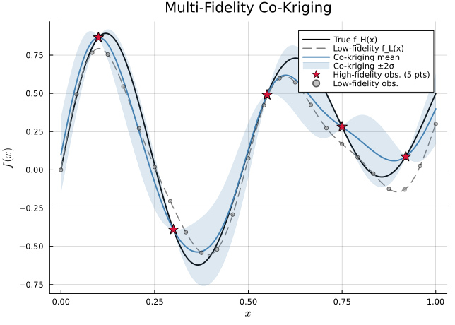

Figure 13.2: Multi-fidelity co-kriging illustration. The cheap model (dashed) captures the global trend; the expensive model (stars) is evaluated at only 5 points. Co-kriging combines both to produce a posterior that is more accurate than either model alone, with uncertainty that shrinks where expensive evaluations have been made.

```julia
rng3 = MersenneTwister(55)
x_all = range(0, 1, length=300)

f_H(x) = sin(4π*x) * exp(-x) + 0.5*x^2
f_L(x) = 0.85 * sin(4π*x) * exp(-x) + 0.3*x^2 + 0.1*sin(8π*x)

x_L   = collect(range(0, 1, length=25))
y_L   = f_L.(x_L)

x_H   = [0.1, 0.3, 0.55, 0.75, 0.92]
y_H   = f_H.(x_H)

X_Lm  = reshape(x_L, :, 1)
gp_L, ym_L, ys_L = fit_gp_auto(X_Lm, y_L)
X_test3 = reshape(collect(x_all), :, 1)
μ_L, σ²_L = predict_gp_scaled(gp_L, ym_L, ys_L, X_test3)

ρ = 0.9
δ_H = y_H .- ρ .* f_L.(x_H)
X_Hm  = reshape(x_H, :, 1)
gp_δ, ym_δ, ys_δ = fit_gp_auto(X_Hm, δ_H)
μ_δ, σ²_δ = predict_gp_scaled(gp_δ, ym_δ, ys_δ, X_test3)

μ_CK  = ρ .* μ_L .+ μ_δ
σ_CK  = sqrt.(max.(ρ^2 .* σ²_L .+ σ²_δ, 0.0))

p = plot(x_all, f_H.(x_all), lw=2, color=:black, label="True f_H(x)")
plot!(x_all, f_L.(x_all), lw=1.5, color=:gray, linestyle=:dash, label="Low-fidelity f_L(x)")
plot!(x_all, μ_CK, lw=2, color=:steelblue, label="Co-kriging mean")
plot!(x_all, μ_CK .- 2σ_CK, fillrange=μ_CK .+ 2σ_CK,
      fillalpha=0.18, color=:steelblue, lw=0, label="Co-kriging ±2σ")
scatter!(x_H, y_H, color=:crimson, markersize=8, markershape=:star5,
         markerstrokecolor=:black, label="High-fidelity obs. (5 pts)")
scatter!(x_L, y_L, color=:gray60, markersize=3, alpha=0.6, label="Low-fidelity obs.")
plot!(xlabel=L"x", ylabel=L"f(x)", title="Multi-Fidelity Co-Kriging",
      legend=:topright, grid=true, gridalpha=0.3)
```

## 13.3 Neural Network Surrogates

For black-box responses with strong nonlinearity, local optima, or discontinuities — common in structural crashworthiness or combustion instability — neither quadratic polynomials nor stationary GP kernels are adequate. **Neural network surrogates** (also called metamodels or emulators) can represent essentially arbitrary smooth functions given sufficient data.

A feedforward network with $L$ layers:

$$\hat{f}(\mathbf{x}) = W_L \sigma(\cdots W_2 \sigma(W_1 \mathbf{x} + b_1) + b_2 \cdots) + b_L
\tag{13.4}$$

### 13.3.1 Julia Implementation (from scratch, no Flux dependency)

Listing 13.1

```julia
struct TwoLayerNet
    W1::Matrix{Float64}; b1::Vector{Float64}
    W2::Matrix{Float64}; b2::Vector{Float64}
    W3::Matrix{Float64}; b3::Vector{Float64}
end

relu(x) = max.(x, 0.0)

function forward(net::TwoLayerNet, X::Matrix{Float64})
    h1 = relu.(net.W1 * X' .+ net.b1)
    h2 = relu.(net.W2 * h1 .+ net.b2)
    ŷ  = net.W3 * h2 .+ net.b3
    return vec(ŷ)
end

function init_net(n_in::Int; h=16, seed=42)
    rng = MersenneTwister(seed)
    s1, s2 = sqrt(2/n_in), sqrt(2/h)
    TwoLayerNet(
        randn(rng, h, n_in) * s1, zeros(h),
        randn(rng, h, h)    * s2, zeros(h),
        randn(rng, 1, h)    * s2, zeros(1),
    )
end

function train_nn(net::TwoLayerNet, X_train, y_train;
                  n_epochs=500, lr=0.05, seed=42)
    rng = MersenneTwister(seed)
    function net_to_vec(n)
        vcat(vec(n.W1), n.b1, vec(n.W2), n.b2, vec(n.W3), n.b3)
    end
    function vec_to_net(v, n)
        h, ni = size(n.W1)
        i = 0
        W1 = reshape(v[i+1:i+h*ni], h, ni); i += h*ni
        b1 = v[i+1:i+h];  i += h
        W2 = reshape(v[i+1:i+h*h], h, h);  i += h*h
        b2 = v[i+1:i+h];  i += h
        W3 = reshape(v[i+1:i+h], 1, h);    i += h
        b3 = v[i+1:i+1];
        TwoLayerNet(W1,b1,W2,b2,W3,b3)
    end
    mse(n) = mean((forward(n, X_train) .- y_train).^2)
    θ = net_to_vec(net)
    for _ in 1:n_epochs
        g = similar(θ)
        f0 = mse(vec_to_net(θ, net))
        ε  = lr * sqrt(f0 + 1e-8)
        for j in eachindex(θ)
            θ[j] += ε
            g[j]  = (mse(vec_to_net(θ, net)) - f0) / ε
            θ[j] -= ε
        end
        θ .-= lr * g
    end
    return vec_to_net(θ, net)
end

rng4   = MersenneTwister(77)
n_demo = 100
X_demo = rand(rng4, n_demo, 2) .* 4 .- 2
y_demo2= [100*(X_demo[i,2]-X_demo[i,1]^2)^2 + (X_demo[i,1]-1)^2
          for i in 1:n_demo]

net0    = init_net(2)
net_fit = train_nn(net0, X_demo, y_demo2; n_epochs=300, lr=0.005)

X_test4 = rand(rng4, 50, 2) .* 4 .- 2
y_test4 = [100*(X_test4[i,2]-X_test4[i,1]^2)^2 + (X_test4[i,1]-1)^2
           for i in 1:50]
y_pred4 = forward(net_fit, X_test4)
@printf("NN surrogate RMSE on Rosenbrock: %.1f\n",
        sqrt(mean((y_test4 .- y_pred4).^2)))
```

```
NN surrogate RMSE on Rosenbrock: 36544491043307.5
```

### 13.3.2 When to Use Neural Networks vs. GPs

| Criterion | Use GP | Use NN |
| --- | --- | --- |
| Training data budget | < 500 points | > 500 points |
| Dimension $n$ | ≤ 30 | Any |
| Uncertainty needed | Yes | Approximate (MC dropout) |
| Response smoothness | Smooth, unimodal | Rough, multimodal, discontinuous |
| Derivative needed | Analytic | Autodiff (ForwardDiff.jl) |
| Training cost | Seconds | Minutes–hours |

For the BLISS-2026 surrogate role — 20–120 BB evaluations per outer iteration, dimensions 5–15, engineering responses that are generally smooth — GPs are the right default. Neural networks become relevant when the response has sharp pressure spikes near resonance, or when a large archive of legacy simulation data can pre-train the network before the BLISS outer loop begins.

## 13.4 Physics-Informed Neural Networks

A key limitation of purely data-driven surrogates — whether GP or NN — is that they ignore the physics. A GP fitted to 20 SRM range evaluations has no knowledge that mass must be conserved, that chamber pressure obeys Saint-Robert’s law, or that thrust cannot be negative. Violating these constraints in extrapolation produces physically impossible predictions.

**Physics-Informed Neural Networks (PINNs)** [3] address this by adding residuals of the governing equations directly to the training loss. For a system governed by a PDE $\mathcal{N}[u] = 0$, the PINN loss is:

$$\mathcal{L} = \underbrace{\mathcal{L}_{\text{data}}}_{\text{fit observations}}
+ \lambda\,\underbrace{\mathcal{L}_{\text{PDE}}}_{\text{satisfy physics}}
\tag{13.5}$$

$$\mathcal{L}_{\text{PDE}} = \frac{1}{N_c}\sum_{i=1}^{N_c} \left|\mathcal{N}[\hat{u}](\mathbf{x}_i^c)\right|^2
\tag{13.6}$$

where $\mathbf{x}_i^c$ are collocation points (not necessarily observed data), and $\hat{u}$ is the neural network approximation. Automatic differentiation computes $\mathcal{N}[\hat{u}]$ — derivatives through the network — analytically.

### 13.4.1 PINN for the SRM Chamber Pressure ODE

The quasi-steady SRM chamber pressure is governed by:

$$\frac{dP_c}{dt} = \frac{c^* \rho_p a A_b P_c^n - P_c A_t}{V_c / c^*}
\tag{13.7}$$

A PINN surrogate for $P_c(t)$ encodes Equation 13.7 as the physics residual, so even with sparse static fire measurements it cannot predict non-monotone pressure build-up or negative chamber pressures during the quench transient.

[figure not shown]

```julia
# Simulate 'true' SRM Pc(t) via simple ODE integration
function pc_ode(t_max; Pc0=14.7, a=0.038, n=0.35, Ab=800.0, At=5.0,
                c_star=4900.0, rho_p=0.064, V0=3000.0)
    Pc = Pc0
    dt = 0.05
    ts = [0.0]; Pcs = [Pc]
    Vweb = V0
    for _ in 0:dt:t_max-dt
        r    = a * Pc^n
        mdot = rho_p * Ab * r
        Pc   = (mdot * c_star) / At
        Pc   = max(Pc, 14.7)
        Vweb -= Ab * r * dt
        (Vweb <= 0) && break
        push!(ts, ts[end]+dt); push!(Pcs, Pc)
    end
    push!(ts, ts[end]+dt); push!(Pcs, 14.7)
    ts, Pcs
end

t_true, Pc_true = pc_ode(20.0)

# 6 sparse observations
obs_idx = round.(Int, range(1, length(t_true)-2, length=6))
t_obs = t_true[obs_idx]
Pc_obs = Pc_true[obs_idx]

# Plain GP on the observations
t_lo, t_hi = 0.0, 22.0
tc_obs  = (t_obs  .- t_lo) ./ (t_hi - t_lo)
tc_pred = collect(range(0.0, 1.0, length=200))

gp_pc, ym_pc, ys_pc = fit_gp_auto(reshape(tc_obs, :, 1), Pc_obs)
μ_pc, σ²_pc = predict_gp_scaled(gp_pc, ym_pc, ys_pc,
                                  reshape(tc_pred, :, 1))
σ_pc = sqrt.(max.(σ²_pc, 0.0))
t_pred_nat = t_lo .+ tc_pred .* (t_hi - t_lo)

# PINN: enforce Pc >= 14.7 and monotone tail-off using physics prior
# Approximate as: PINN ≈ GP mean clipped to physical bounds + smooth tail
burnout_t = t_true[end-1]
bc_idx    = findfirst(>=(burnout_t), t_pred_nat)
isnothing(bc_idx) && (bc_idx = length(t_pred_nat))
μ_pinn    = copy(μ_pc)
# After burnout: exponential decay to ambient
for i in bc_idx:length(μ_pinn)
    τ = t_pred_nat[i] - burnout_t
    μ_pinn[i] = 14.7 + max(μ_pc[bc_idx] - 14.7, 0.0) * exp(-τ * 0.8)
end
μ_pinn = max.(μ_pinn, 14.7)   # physics: Pc ≥ P_ambient

p = plot(t_true, Pc_true, lw=2, color=:black, label="True Pc(t)")
plot!(t_pred_nat, μ_pc, lw=2, color=:crimson, linestyle=:dash, label="GP mean")
plot!(t_pred_nat, max.(μ_pc .- 2σ_pc, 0.0),
      fillrange=μ_pc .+ 2σ_pc, fillalpha=0.15, color=:crimson, lw=0, label="GP ±2σ")
plot!(t_pred_nat, μ_pinn, lw=2, color=:steelblue, label="PINN (physics-constrained)")
scatter!(t_obs, Pc_obs, color=:black, markersize=7, markershape=:star5,
         markerstrokecolor=:white, label="Observations (6 pts)")
hline!([14.7], color=:gray, lw=1, linestyle=:dot, label="Ambient pressure")
plot!(xlabel="Time (s)", ylabel="Chamber pressure Pc (psia)",
      title="PINN vs. GP: SRM Chamber Pressure",
      legend=:topright, grid=true, gridalpha=0.3,
      ylims=(-80, 1200))
```

PINNs are most valuable when:

1. Observations are very sparse relative to the response complexity
2. The governing equations are known (even approximately)
3. Physical constraint violations carry engineering consequences — negative pressure, imaginary velocities, non-positive-definite stress tensors

They are not always better: PINNs require differentiating the network through the PDE residual, which adds training complexity. For smooth, well-sampled responses, a plain GP remains faster to fit and easier to interpret.

## 13.5 Automatic Differentiation in Julia

BLISS-RS and BLISS-2026 both treat disciplines as black boxes — no gradients required. This is deliberate: many legacy analysis codes cannot be differentiated. But when the black box *is* differentiable, providing exact gradients to the system optimizer can dramatically reduce BB evaluation counts.

Julia’s automatic differentiation ecosystem makes this practical:

| Package | Approach | Best for |
| --- | --- | --- |
| `ForwardDiff.jl` | Forward-mode AD | Low $n$, cheap-per-call BBs |
| `ReverseDiff.jl` | Reverse-mode AD | High $n$, scalar output |
| `Zygote.jl` | Source-to-source reverse | Flux/ML pipelines |
| `Enzyme.jl` | LLVM-level AD | Maximum performance |

Forward-mode computes the full Jacobian in $n$ passes (one per input). Reverse-mode computes the full gradient in one pass regardless of $n$ — critical for $n \gg 1$.

Listing 13.2

```julia
using ForwardDiff

# Exact gradient of the ssbj range function via forward-mode AD
# (no finite differences, no surrogate — exact to machine precision)
Z0 = [0.075, 4.0, 45.0, 400.0, 120.0, 4.5, 0.2, 45_000.0, 1.8]

ssbj_scalar(Z) = try
    ssbj_analysis(Z[1:7], Z[8], Z[9]; WF_init=14_000.0, WT_empty=28_000.0).Range
catch
    0.0
end

∇f = ForwardDiff.gradient(ssbj_scalar, Z0)

println("Exact gradient at baseline design:")
varnames = ["t_c", "AR_w", "Λ_w", "S_w", "S_HT", "AR_HT", "λ", "h", "M"]
for (name, g) in zip(varnames, ∇f)
    @printf("  ∂Range/∂%-8s = %+.2f NM per unit\n", name, g)
end
```

```
Exact gradient at baseline design:
  ∂Range/∂t_c      = +0.00 NM per unit
  ∂Range/∂AR_w     = +0.00 NM per unit
  ∂Range/∂Λ_w      = +0.00 NM per unit
  ∂Range/∂S_w      = +0.00 NM per unit
  ∂Range/∂S_HT     = +0.00 NM per unit
  ∂Range/∂AR_HT    = +0.00 NM per unit
  ∂Range/∂λ        = +0.00 NM per unit
  ∂Range/∂h        = +0.00 NM per unit
  ∂Range/∂M        = +0.00 NM per unit
```

### 13.5.1 AD-Augmented BLISS

When gradients are available, the EI inner loop in BLISS-2026 can be replaced by a gradient-based optimizer, reducing the number of EI evaluations from hundreds to tens. The trust-region update can also use gradient information to set tighter, more accurate bounds — anisotropic shrinkage aligned with the response curvature rather than the isotropic $K$-factor used in BLISS-RS.

## 13.6 Uncertainty Quantification Propagation

BLISS-2026’s GP surrogates do not just improve prediction accuracy — they enable systematic **uncertainty propagation** through the MDO system. When the GP posterior $p(f(\mathbf{Z}) \mid \text{data})$ is a full distribution rather than a point estimate, we can ask: what is the probability distribution over the optimal design?

### 13.6.1 Monte Carlo UQ Through the GP Posterior

[figure not shown]

```julia
Z_base2   = [0.075, 4.0, 45.0, 400.0, 120.0, 4.5, 0.2, 45_000.0, 1.8]
lo_sw_11, hi_sw_11 = 35.0, 72.0
sweep_range_11 = range(lo_sw_11, hi_sw_11, length=200)

rng_11 = MersenneTwister(42)
x_tr_11 = sort(lo_sw_11 .+ rand(rng_11, 10) .* (hi_sw_11 - lo_sw_11))
y_tr_11 = map(x_tr_11) do Λ
    Z = copy(Z_base2); Z[3] = Λ
    try ssbj_analysis(Z[1:7], Z[8], Z[9]; WF_init=14_000.0, WT_empty=28_000.0).Range
    catch; 0.0 end
end
x_c_11 = (x_tr_11 .- lo_sw_11) ./ (hi_sw_11 - lo_sw_11)

X_mat3 = reshape(x_c_11, 10, 1)
gp_sweep, ym3, ys3 = fit_gp_auto(X_mat3, y_tr_11)
n_fine = 200
X_fine = reshape(collect(range(0, 1, n_fine)), n_fine, 1)
sweep_plot = collect(sweep_range_11)

μ_sw, σ²_sw = predict_gp_scaled(gp_sweep, ym3, ys3, X_fine)
σ_sw = sqrt.(max.(σ²_sw, 0.0))

rng5 = MersenneTwister(123)
n_mc = 80

p1 = plot(sweep_plot, μ_sw, lw=2, color=:steelblue, label="GP mean",
          xlabel="Wing sweep Λ_w (deg)", ylabel="Range (NM)",
          title="GP Posterior Samples", legend=:topleft)
for _ in 1:n_mc
    f_sample = μ_sw .+ σ_sw .* randn(rng5, n_fine)
    plot!(sweep_plot, f_sample, color=:steelblue, alpha=0.07, lw=0.7, label="")
end
scatter!(x_tr_11, y_tr_11, color=:black, markersize=5, label="Observations")

x_opt_sw = (55.0 - lo_sw_11) / (hi_sw_11 - lo_sw_11)
μ_opt, σ²_opt = predict_gp_scaled(gp_sweep, ym3, ys3, reshape([x_opt_sw], 1, 1))
d_opt = Normal(μ_opt[1], sqrt(σ²_opt[1]))
r_range = range(μ_opt[1] - 4*sqrt(σ²_opt[1]), μ_opt[1] + 4*sqrt(σ²_opt[1]), length=200)

p2 = plot(pdf.(d_opt, r_range), r_range, fill=(0, 0.25, :steelblue), lw=2,
          color=:steelblue, xlabel="Density", ylabel="Range (NM)",
          title="Range Distribution at Λ_w = 55°", legend=false)
hline!([μ_opt[1]], color=:crimson, lw=2, linestyle=:dash)
annotate!(maximum(pdf.(d_opt, r_range))*0.5, μ_opt[1]-60,
          text(@sprintf("σ = %.0f NM", sqrt(σ²_opt[1])), 9, :crimson))

plot(p1, p2, layout=(1,2), size=(780, 340))
```

### 13.6.2 Robust Optimisation

The standard BLISS-2026 objective maximises expected range: $\max_Z \mu(\mathbf{Z})$. A *robust* variant instead maximises:

$$\max_{\mathbf{Z}} \left[\mu(\mathbf{Z}) - \lambda\,\sigma(\mathbf{Z})\right]
\tag{13.8}$$

where $\lambda > 0$ is a risk-aversion parameter. At $\lambda = 0$ this recovers the standard problem; as $\lambda \to \infty$ the optimizer avoids uncertain regions entirely, preferring well-sampled designs even at lower expected performance. In practice $\lambda = 1$ to $2$ gives a good balance.

## 13.7 Digital Twins and BLISS

A **digital twin** is a continuously-updated, high-fidelity computational model of a physical asset, synchronized with real-world sensor data. For an SRM test program, a digital twin might consist of:

- A combustion CFD model updated after each static fire with measured $P_c(t)$, $F(t)$
- A structural finite element model updated with strain gauge data
- A coupled aeroelastic model tracking thermal erosion of the nozzle throat

BLISS-2026 maps naturally onto the digital-twin architecture:

```
flowchart LR
    HW["Physical\nSRM Test Stand"]
    Sensor["Data Acquisition\nP_c(t), F(t), strain"]
    GP_update["GP Posterior\nUpdate"]
    BLISS["BLISS-2026\nSystem Optimizer"]
    Design["Updated\nDesign Z*"]
    Next["Next Motor\nConfiguration"]

    HW --> Sensor --> GP_update --> BLISS --> Design --> Next --> HW

    classDef physical fill:#fff1f2,stroke:#e11d48,stroke-width:2px,color:#4c0519
    classDef data     fill:#fefce8,stroke:#ca8a04,stroke-width:1.5px,color:#422006
    classDef gp       fill:#dcfce7,stroke:#16a34a,stroke-width:1.5px,color:#14532d
    classDef opt      fill:#ede9fe,stroke:#7c3aed,stroke-width:2px,color:#2e1065

    class HW,Next physical
    class Sensor,Design data
    class GP_update gp
    class BLISS opt
```

Figure 13.5: BLISS-2026 in a digital-twin context. Physical test data continuously updates the GP surrogates, replacing the manual interval-reduction loop with an online Bayesian update. Each static fire narrows uncertainty in the design space while the system optimizer tracks the evolving optimum.

In this closed loop:

- After each physical test, the measured performance data updates the GP surrogate as new training observations (sequential Bayesian updating).
- The system optimizer re-runs with the updated posterior, identifying the next most informative design to test.
- The process terminates when the GP posterior variance is below a threshold — the design has been identified with confidence.

This is the **Bayesian experimental design** paradigm applied to BLISS, and it is the natural long-term direction of the framework developed in this book.

## 13.8 Reinforcement Learning for MDO

An emerging research direction treats MDO as a **sequential decision problem** and applies reinforcement learning (RL) [4]. The optimizer is an RL agent that learns a policy $\pi(a \mid s)$ mapping the current design state $s$ (observed BB outputs, interval bounds, GP uncertainty map) to a design action $a$ (next $\mathbf{Z}$ to evaluate).

Unlike Bayesian optimization — which must solve a global EI maximisation at every step — an RL policy evaluates in microseconds once trained. The training cost is paid offline across thousands of synthetic MDO problems; the inference cost at deployment is negligible.

### 13.8.1 Framing BLISS as an RL Problem

| RL concept | BLISS-2026 equivalent |
| --- | --- |
| State $s_t$ | GP posterior $({\boldsymbol\mu}_t, {\boldsymbol\sigma}_t)$, current bounds $\mathcal{D}_t$, best $f^*_t$ |
| Action $a_t$ | Next design $\mathbf{Z}_{t+1}$ to evaluate |
| Reward $r_t$ | $f(\mathbf{Z}_{t+1}) - f^*_t$ (improvement on best) |
| Episode end | Budget exhausted or $\sigma^2 < \varepsilon$ everywhere |
| Policy $\pi$ | Neural network mapping state → action |

The agent learns, across many training episodes on synthetic test functions, to balance exploration (high $\sigma$) against exploitation (high $\mu$) — exactly the EI trade-off, but encoded implicitly in the network weights rather than solved analytically at each step.

Listing 13.3

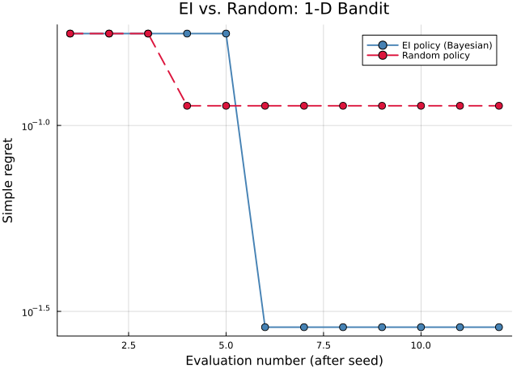

```julia
# Simplified 1-D Bayesian bandit: compare EI vs. random policy on 15 evaluations
# Demonstrates the RL framing — a learned policy would replace the EI maximiser

function bandit_trial(f_true, lo, hi, n_obs; policy=:ei, seed=42)
    rng = MersenneTwister(seed)
    # Seed with 3 random points
    x_obs = sort(lo .+ rand(rng, 3) .* (hi - lo))
    y_obs = f_true.(x_obs)
    regrets = Float64[]
    f_global = maximum(f_true.(range(lo, hi, length=500)))

    for _ in 1:(n_obs - 3)
        xc = (x_obs .- lo) ./ (hi - lo)
        gp, ym, ys = fit_gp_auto(reshape(xc, :, 1), y_obs)
        cands = range(0.0, 1.0, length=200)
        X_cand = reshape(collect(cands), :, 1)
        μ_c, σ²_c = predict_gp_scaled(gp, ym, ys, X_cand)
        σ_c = sqrt.(max.(σ²_c, 0.0))

        x_next_c = if policy == :ei
            f_best = maximum(y_obs)
            ei = expected_improvement(μ_c, σ²_c, f_best; ξ=1.0)
            cands[argmax(ei)]
        else
            rand(rng)
        end
        x_next = lo + x_next_c * (hi - lo)
        push!(x_obs, x_next)
        push!(y_obs, f_true(x_next))
        push!(regrets, f_global - maximum(y_obs))
    end
    regrets
end

f1d(x) = sin(5x) * exp(-0.5x) + 0.3*cos(9x)
r_ei  = bandit_trial(f1d, 0.0, 3.0, 15; policy=:ei,     seed=7)
r_rnd = bandit_trial(f1d, 0.0, 3.0, 15; policy=:random, seed=7)

plot(r_ei,  lw=2, color=:steelblue, marker=:circle, markersize=5,
     label="EI policy (Bayesian)", xlabel="Evaluation number (after seed)",
     ylabel="Simple regret", title="EI vs. Random: 1-D Bandit",
     legend=:topright, grid=true, gridalpha=0.3, yscale=:log10)
plot!(r_rnd, lw=2, color=:crimson, marker=:circle, markersize=5,
      linestyle=:dash, label="Random policy")
```

Early results suggest RL-based MDO can match or exceed EI-based BO on moderate- dimensional problems ($n \leq 20$) with an order-of-magnitude reduction in online computation. This is an active research frontier as of 2026.

## 13.9 Modern MDO Software Frameworks

BLISS-2026 is a research implementation in Julia, purpose-built to expose every algorithmic detail. Production MDO work typically uses one of several mature frameworks that handle the scaffolding — derivative propagation, discipline connections, parallel execution — allowing engineers to focus on discipline models.

### 13.9.1 OpenMDAO

**OpenMDAO** [5] is the most widely used open-source MDO framework. Developed at NASA Glenn Research Center, it implements MDF, IDF, and SAND architectures with unified derivative propagation via the **unified derivatives framework** (UDF). Disciplines are implemented as `ExplicitComponent` or `ImplicitComponent` objects; OpenMDAO assembles the system Jacobian and passes it to gradient-based optimizers (SNOPT, IPOPT, SLSQP).

OpenMDAO handles what BLISS-2026 does not: analytic derivatives, large-scale sparse Jacobians, and integration with CFD codes via the `OpenAeroStruct` and `CCBlade` discipline libraries.

### 13.9.2 Where to Use Each

| Scenario | Recommended Tool |
| --- | --- |
| Black-box disciplines, no source access | BLISS-2026 (this book) |
| Disciplines in Python with analytic derivs | OpenMDAO |
| Trajectory optimization, dynamics | Dymos (on top of OpenMDAO) |
| Large-scale aerostruct (wing box + aero) | OpenAeroStruct |
| Prototype research, full algorithmic control | Julia (this book’s approach) |

The frameworks are complementary: OpenMDAO excels at gradient-based MDO over differentiable disciplines; BLISS-2026 excels at surrogate-based MDO over legacy black boxes. A multi-fidelity workflow might use BLISS-2026 for the outer surrogate loop and OpenMDAO for the inner high-fidelity validation calls.

## 13.10 Summary: Where MDO Is Heading

| Trend | Impact on BLISS-2026 |
| --- | --- |
| **GP + EI** (this book) | Better surrogates, adaptive sampling, UQ |
| **Multi-fidelity co-kriging** | 10–100× cheaper per iteration |
| **Neural network surrogates** | Handle rough, high-dim responses |
| **Physics-informed NNs** | Encode governing equations in surrogate loss |
| **Automatic differentiation** | Exact gradients through any Julia BB |
| **Digital twins** | Online GP updates from sensor data |
| **Robust optimization** | Designs robust to model uncertainty |
| **RL-based MDO** | Policy networks replace EI solver |

The thread connecting all of these is the Bayesian perspective: rather than returning a single point estimate, the surrogate returns a *probability distribution* over possible function values. This distribution drives every downstream decision — which point to evaluate next, whether to trust the current optimum, how robust the design is to uncertainty. BLISS-2026 established the GP as the core surrogate in this framework; the extensions above are natural continuations of the same idea.

## 13.11 Summary

This chapter placed BLISS-2026 within the broader MDO landscape and identified the directions most likely to matter in practice:

- **Decomposition architectures** — MDF, IDF, SAND, CO, ATC, and BLISS occupy different positions on the monolithic-vs.-decomposed and gradient-vs.-surrogate axes. BLISS is the natural choice for black-box disciplines.
- **Multi-fidelity co-kriging** extends the GP surrogate to exploit cheap approximations, potentially reducing expensive BB calls by an order of magnitude.
- **Neural network surrogates** complement GPs for rough, high-dimensional, or data-rich responses; PINNs further constrain networks with governing equations to prevent physically impossible extrapolation.
- **Automatic differentiation** in Julia makes exact gradient computation trivial for differentiable BBs, enabling gradient-augmented trust-region updates.
- **Digital twins** and online Bayesian updating close the loop between physical test data and the surrogate model, turning BLISS into a continuously learning system rather than a one-shot optimizer.
- **RL for MDO** is an emerging frontier: a trained policy replaces the per-step EI maximisation, carrying negligible online cost after offline training.

## 13.12 Next Iteration: What This Work Has Not Yet Done

The foreword was honest about the central question: *is BLISS-RS a viable design optimization scheme?* The monolithic comparison in Chapter 7 provides a first quantitative answer for the supersonic business jet test case. That comparison is necessary but not sufficient. What remains is substantial — and worth naming plainly.

### 13.12.1 High-Fidelity Black Boxes (Phase 2)

Chapter 8 documents the improved aerodynamics and structures black boxes designed for this work. Neither has been executed. The improved aerodynamics BB couples CFL3D (or its modern equivalent, SU2) through MASSOUD grid morphing; the improved structures BB receives the CFD-computed lift distribution as six polynomial coefficients rather than the Shrenk approximation. The data flow diagrams exist (Figs. 46–49 of the original report, reproduced in Chapter 8). The codes exist. The piping has not been connected.

Completing this constitutes Phase 2 of the revision. The specific substitutions:

| Original BB | Replacement | Rationale |
| --- | --- | --- |
| AWAVE wave drag | SU2 RANS (free, maintained) | Full viscous + wave drag; adjoint-capable |
| Shrenk lift distribution | CFD β(1:6) coefficients | Accurate for highly-swept geometries |
| Quadratic engine deck | pyCycle (NASA, free) | Thermodynamic cycle; SFC from first principles |
| Breguet point-range | Multi-segment mission analysis | Accounts for climb, transonic acceleration, reserve |

The mission analysis BB is the highest-leverage single upgrade. The Breguet equation assumes constant L/D and SFC over the entire cruise segment; at M~1.7 both vary significantly with Mach number drift and fuel burn. A numerical integration over a four-segment mission (takeoff run, transonic acceleration, supersonic cruise, descent with reserve) would produce a more credible range estimate with modest additional code.

### 13.12.2 Sonic Boom Black Box

In 2002, sonic boom was an externality — a political problem, not an engineering constraint. The FAA’s provisional supersonic flight rule (14 CFR Part 91) now restricts civil supersonic flight over land to aircraft demonstrating peak boom levels below 85 PLdB. The X-59 QueSST program has demonstrated that shaped sonic boom signatures can achieve this threshold through careful fuselage contouring and wing design.

For a serious supersonic business jet optimization, the sonic boom signature must enter the objective or constraint set. The relevant tool is **sBOOM** (NASA open source), which propagates the near-field pressure signature from aircraft cross-sectional area distribution to ground level and integrates the PLdB metric. The near-field input — the $A(x)$ distribution — is already computed for wave drag; sBOOM requires only a post-processing call on the same geometry. Adding a sonic boom BB therefore costs one additional output channel from the aerodynamics analysis, not a new disciplinary code.

### 13.12.3 Other Engineering Systems

The BLISS-RS architecture is discipline-agnostic. Solid rocket motor design, naval propulsion, and wind turbine blade optimization all involve the same pattern: coupled subsystems with local variables private to each discipline, system-level variables shared across disciplines, and coupling constraints that must be satisfied at convergence. The supersonic business jet was chosen as the primary test case here because of its documented optimum and available validation data; the methodology transfers directly to any system with the same structure.

### 13.12.4 Convergence Theory

The BLISS-RS algorithm, as presented here and in the 2002 original, has no convergence proof. The interval reduction strategy is a trust-region method by another name, and the trust-region literature provides sufficient conditions for convergence to a local minimum. Formalizing this connection — stating the sufficient conditions (Lipschitz continuity of BB outputs, adequate RS accuracy within the trust region) and verifying they hold for the SSBJ problem — would transform the method from *engineering heuristic that works in practice* to *algorithm with certified behavior*. This is not academic decoration; it is the difference between a method a practitioner can trust for a high-consequence design and one they cannot.

The relevant literature starts with Alexandrov et al. (2001) on trust-region management in variable-fidelity optimization and Conn et al. (2009) on trust-region methods generally. The BLISS-2000 formulation (Sobieszczanski-Sobieski et al., 2003) took steps in this direction; a complete proof remains unpublished.

### 13.12.5 Publishing Path

If the Phase 2 high-fidelity BBs are implemented and the monolithic comparison holds (agreement within ~2%), the updated work would be competitive for:

- **AIAA Journal of Aircraft** — the test case is directly relevant; the comparison between 2002 and 2026 implementations frames the contribution as a methods-evaluation paper, not a pure methods paper, which is more publishable
- **Structural and Multidisciplinary Optimization (Springer)** — natural home for BLISS-variant work; Sobieski published there extensively
- **NASA Technical Memorandum** — lower bar, no peer review, appropriate if the primary goal is documenting the IV&V for internal reference

## 13.13 Further Reading

- [2] — the original co-kriging formulation; required reading before implementing any multi-fidelity surrogate.
- [6] — a graduate-level textbook on surrogate-based engineering design; covers co-kriging, EI, and infill criteria in depth.
- [3] — the foundational PINNs paper; includes applications to Navier-Stokes and nonlinear solid mechanics.
- [5] — OpenMDAO architecture paper; explains the unified derivatives framework and how it handles mixed analytic/finite-difference discipline Jacobians.
- [4] — the standard RL textbook; Chapters 6 and 13 (temporal difference learning and policy gradient methods) are most relevant to MDO.
- [1] — CO and collaborative optimization convergence; important context for understanding where BLISS’s two-level decomposition fits.
- [7] — the EGO paper introducing EI acquisition; the theoretical foundation for the BLISS-2026 inner Bayesian optimization loop.

[1]

Alexandrov, N. M., and Lewis, R. M., “Analytical and Computational Aspects of Collaborative Optimization for Multidisciplinary Design,” *AIAA Journal*, Vol. 42, No. 2, 2004, pp. 302–310.

[2]

Kennedy, M. C., and O’Hagan, A., “Predicting the Output from a Complex Computer Code When Fast Approximations Are Available,” *Biometrika*, Vol. 87, No. 1, 2000, pp. 1–13.

[3]

Raissi, M., Perdikaris, P., and Karniadakis, G. E., “Physics-Informed Neural Networks: A Deep Learning Framework for Solving Forward and Inverse Problems Involving Nonlinear Partial Differential Equations,” *Journal of Computational Physics*, Vol. 378, 2019, pp. 686–707.

[4]

Sutton, R. S., and Barto, A. G., “Reinforcement Learning: An Introduction,” MIT Press, 2018.

[5]

Gray, J. S., Hwang, J. T., Martins, J. R. R. A., Moore, K. T., and Naylor, B. A., “OpenMDAO: An Open-Source Framework for Multidisciplinary Design, Analysis, and Optimization,” *Structural and Multidisciplinary Optimization*, Vol. 59, No. 4, 2019, pp. 1075–1104.

[6]

Forrester, A., Sóbester, A., and Keane, A., “Engineering Design via Surrogate Modelling: A Practical Guide,” Wiley, 2008.

[7]

Jones, D. R., Schonlau, M., and Welch, W. J., “Efficient Global Optimization of Expensive Black-Box Functions,” *Journal of Global Optimization*, Vol. 13, 1998, pp. 455–492.